# DATA SCIENCE PROJECT

## Data Analysis on Renting Options in Sydney: Airbnb

Airbnb is an online platform for organizing or offering services for accommodation focusing mainly on homestays and holiday experiences. The company is based in San Francisco, California, United States. Users can list their homes/properties on Airbnb as hosts and people can make online bookings by getting in contact with their respective hosts.

We are going to do analysis using various variables such as price ratings house rules etc. which are primarily focused by consumers to use Airbnb and provide a report in an interactive visualization format focusing on all kinds of audiences including naive users as well. Moreover we will come up with a prediction model to predict the patterns or trends between the Airbnb data and Australian Census data.

```python
import numpy as np
import pandas as pd
import seaborn as sns
import matplotlib.pyplot as plt
%matplotlib inline
from matplotlib import rcParams
from wordcloud import WordCloud, STOPWORDS
from nltk.corpus import stopwords
import collections
import cufflinks as cf
import plotly.offline
cf.go_offline()
cf.set_config_file(offline=False, world_readable=True)
from sklearn.model_selection import train_test_split
from sklearn import linear_model
from sklearn.metrics import r2_score
from sklearn.linear_model import LogisticRegression
from sklearn.linear_model import LinearRegression
from sklearn.metrics import confusion_matrix, accuracy_score
from sklearn.feature_selection import RFE
from sklearn.preprocessing import StandardScaler
from sklearn.neighbors import KNeighborsClassifier
from sklearn.neural_network import MLPClassifier
from sklearn.metrics import accuracy_score
from sklearn.model_selection import cross_val_score
from sklearn import tree
from sklearn.neural_network import MLPRegressor
from sklearn.tree import DecisionTreeRegressor
import warnings; warnings.simplefilter('ignore')
pd.set_option('display.float_format', lambda x: '%.3f' % x)
```

# Interpretation

Above mentioned libraries are imported for the project. As the progress is made we will be importing other libraries as per the requirement.

**pd.set_option is used to format the exponential values in the variables.**

# Reading the **`Airbnb dataset`** 🏘️.

```python
airbnb_complete_data= pd.read_csv("Dataset/listings.csv", index_col="id")
print("The complete dataset of airbnb has shape :" ,airbnb_complete_data.shape)
airbnb_complete_data.head()
```

```
The complete dataset of airbnb has shape : (38080, 105)
```

| id | listing_url | scrape_id | last_scraped | name | summary | space | description | experiences_offered | neighborhood_overview | notes | ... | instant_bookable | is_business_travel_ready | cancellation_policy | require_guest_profile_picture | require_guest_phone_verification | calculated_host_listings_count | calculated_host_listings_count_entire_homes | calculated_host_listings_count_private_rooms | calculated_host_listings_count_shared_rooms | reviews_per_month |
| --- | --- | --- | --- | --- | --- | --- | --- | --- | --- | --- | --- | --- | --- | --- | --- | --- | --- | --- | --- | --- | --- |
| 11156 | https://www.airbnb.com/rooms/11156 | 20190700000000.000 | 11-07-19 | An Oasis in the City | Very central to the city which can be reached ... | Potts Pt. is a vibrant and popular inner-city... | Very central to the city which can be reached ... | none | It is very close to everything and everywhere,... | $150.00 key security deposit, refundable on re... | ... | f | f | moderate | f | f | 1 | 0 | 1 | 0 | 1.580 |
| 12351 | https://www.airbnb.com/rooms/12351 | 20190700000000.000 | 11-07-19 | Sydney City & Harbour at the door | Come stay with Vinh & Stuart (Awarded as one o... | We're pretty relaxed hosts, and we fully appre... | Come stay with Vinh & Stuart (Awarded as one o... | none | Pyrmont is an inner-city village of Sydney, on... | We've a few reasons for the 6.00pm arrival tim... | ... | f | f | strict_14_with_grace_period | t | t | 2 | 0 | 2 | 0 | 4.730 |
| 14250 | https://www.airbnb.com/rooms/14250 | 20190700000000.000 | 10-07-19 | Manly Harbour House | Beautifully renovated, spacious and quiet, our... | Our home is a thirty minute walk along the sea... | Beautifully renovated, spacious and quiet, our... | none | Balgowlah Heights is one of the most prestigio... | NaN | ... | f | f | strict_14_with_grace_period | f | f | 2 | 2 | 0 | 0 | 0.050 |
| 15253 | https://www.airbnb.com/rooms/15253 | 20190700000000.000 | 10-07-19 | Stunning Penthouse Apartment In Heart Of The City | Penthouse living in a great central location: ... | A charming two-level, two-bedroom, two-bathroo... | Penthouse living in a great central location: ... | none | The location is really central and there is nu... | The apartment is on the top floor with 4 fligh... | ... | t | f | strict_14_with_grace_period | f | f | 3 | 2 | 1 | 0 | 3.600 |
| 20865 | https://www.airbnb.com/rooms/20865 | 20190700000000.000 | 11-07-19 | 3 BED HOUSE + 1 BED STUDIO Balmain | Hi! We are a married professional couple with ... | HOUSE : _________ * DUCTED AIR CONDITIONING IN... | Hi! We are a married professional couple with ... | none | BALMAIN is an older inner city village / subur... | During your stay guests may use the landline f... | ... | f | f | strict_14_with_grace_period | t | t | 1 | 1 | 0 | 0 | 0.170 |

5 rows × 105 columns

# Interpretation

```python
print(airbnb_complete_data.dtypes)
```

```
listing_url                                      object
scrape_id                                       float64
last_scraped                                     object
name                                             object
summary                                          object
space                                            object
description                                      object
experiences_offered                              object
neighborhood_overview                            object
notes                                            object
transit                                          object
access                                           object
interaction                                      object
house_rules                                      object
thumbnail_url                                   float64
medium_url                                      float64
picture_url                                      object
xl_picture_url                                  float64
host_id                                           int64
host_url                                         object
host_name                                        object
host_since                                       object
host_location                                    object
host_about                                       object
host_response_time                               object
host_response_rate                               object
host_acceptance_rate                            float64
host_is_superhost                                object
host_thumbnail_url                               object
host_picture_url                                 object
                                                 ...
has_availability                                 object
availability_30                                   int64
availability_60                                   int64
availability_90                                   int64
availability_365                                  int64
calendar_last_scraped                            object
number_of_reviews                                 int64
number_of_reviews_ltm                             int64
first_review                                     object
last_review                                      object
review_scores_rating                            float64
review_scores_accuracy                          float64
review_scores_cleanliness                       float64
review_scores_checkin                           float64
review_scores_communication                     float64
review_scores_location                          float64
review_scores_value                             float64
requires_license                                 object
license                                          object
jurisdiction_names                              float64
instant_bookable                                 object
is_business_travel_ready                         object
cancellation_policy                              object
require_guest_profile_picture                    object
require_guest_phone_verification                 object
calculated_host_listings_count                    int64
calculated_host_listings_count_entire_homes       int64
calculated_host_listings_count_private_rooms      int64
calculated_host_listings_count_shared_rooms       int64
reviews_per_month                               float64
Length: 105, dtype: object
```

# Interpretation

We are checking the data types of each variable of the airbnb dataset.

```python
airbnb_complete_data.describe()
```

|  | scrape_id | thumbnail_url | medium_url | xl_picture_url | host_id | host_acceptance_rate | host_listings_count | host_total_listings_count | neighbourhood_group_cleansed | zipcode | ... | review_scores_checkin | review_scores_communication | review_scores_location | review_scores_value | jurisdiction_names | calculated_host_listings_count | calculated_host_listings_count_entire_homes | calculated_host_listings_count_private_rooms | calculated_host_listings_count_shared_rooms | reviews_per_month |
| --- | --- | --- | --- | --- | --- | --- | --- | --- | --- | --- | --- | --- | --- | --- | --- | --- | --- | --- | --- | --- | --- |
| count | 38080.000 | 0.000 | 0.000 | 0.000 | 38080.000 | 0.000 | 38054.000 | 38054.000 | 0.000 | 37939.000 | ... | 25997.000 | 26028.000 | 25997.000 | 25994.000 | 0.000 | 38080.000 | 38080.000 | 38080.000 | 38080.000 | 27222.000 |
| mean | 20190700000000.000 | nan | nan | nan | 76016308.962 | nan | 8.749 | 8.749 | nan | 2070.456 | ... | 9.721 | 9.728 | 9.688 | 9.337 | nan | 7.112 | 6.161 | 0.826 | 0.125 | 1.067 |
| std | 0.000 | nan | nan | nan | 74806520.125 | nan | 30.590 | 30.590 | nan | 96.494 | ... | 0.816 | 0.832 | 0.746 | 1.044 | nan | 23.848 | 23.910 | 1.879 | 1.383 | 1.474 |
| min | 20190700000000.000 | nan | nan | nan | 12894.000 | nan | 0.000 | 0.000 | nan | 1783.000 | ... | 2.000 | 2.000 | 2.000 | 2.000 | nan | 1.000 | 0.000 | 0.000 | 0.000 | 0.010 |
| 25% | 20190700000000.000 | nan | nan | nan | 15739069.000 | nan | 1.000 | 1.000 | nan | 2022.000 | ... | 10.000 | 10.000 | 10.000 | 9.000 | nan | 1.000 | 0.000 | 0.000 | 0.000 | 0.130 |
| 50% | 20190700000000.000 | nan | nan | nan | 46761195.500 | nan | 1.000 | 1.000 | nan | 2035.000 | ... | 10.000 | 10.000 | 10.000 | 10.000 | nan | 1.000 | 1.000 | 0.000 | 0.000 | 0.430 |
| 75% | 20190700000000.000 | nan | nan | nan | 122019195.500 | nan | 3.000 | 3.000 | nan | 2096.000 | ... | 10.000 | 10.000 | 10.000 | 10.000 | nan | 2.000 | 1.000 | 1.000 | 0.000 | 1.410 |
| max | 20190700000000.000 | nan | nan | nan | 274727754.000 | nan | 438.000 | 438.000 | nan | 4971.000 | ... | 10.000 | 10.000 | 10.000 | 10.000 | nan | 197.000 | 197.000 | 21.000 | 26.000 | 29.780 |

8 rows × 45 columns

# Interpretation

We are depicting statistical values for the dataset such as **`count`** (total number of values) , **`mean`** (average values of each variable), **`standard deviation`** (how a value is deviated from the central value), **`percentiles`** as well.

```python
airbnb_cleaned_data=airbnb_complete_data[["name","description","experiences_offered","transit","host_id","host_name","host_location","host_response_rate","host_is_superhost","host_listings_count","host_verifications","host_identity_verified","street","neighbourhood","neighbourhood_cleansed","city","state","zipcode","market","smart_location","is_location_exact","property_type","room_type","accommodates","bathrooms","bedrooms","beds","bed_type","amenities","price","security_deposit","guests_included","extra_people","minimum_nights","maximum_nights","has_availability","availability_30","availability_60","availability_90","availability_365","number_of_reviews","number_of_reviews_ltm","requires_license","instant_bookable","cancellation_policy","require_guest_phone_verification","calculated_host_listings_count","reviews_per_month", "house_rules"]]
print("After selecting required columns, dataset has shape:",airbnb_cleaned_data.shape)
airbnb_cleaned_data.head()
```

```
After selecting required columns, dataset has shape: (38080, 49)
```

| id | name | description | experiences_offered | transit | host_id | host_name | host_location | host_response_rate | host_is_superhost | host_listings_count | ... | availability_365 | number_of_reviews | number_of_reviews_ltm | requires_license | instant_bookable | cancellation_policy | require_guest_phone_verification | calculated_host_listings_count | reviews_per_month | house_rules |
| --- | --- | --- | --- | --- | --- | --- | --- | --- | --- | --- | --- | --- | --- | --- | --- | --- | --- | --- | --- | --- | --- |
| 11156 | An Oasis in the City | Very central to the city which can be reached ... | none | It is 7 minutes walk to the Kings Cross.train ... | 40855 | Colleen | Potts Point, New South Wales, Australia | 50% | f | 1.000 | ... | 354 | 185 | 10 | f | f | moderate | f | 1 | 1.580 | Be considerate. No showering after 2330h. |
| 12351 | Sydney City & Harbour at the door | Come stay with Vinh & Stuart (Awarded as one o... | none | Our home is centrally located and an easy walk... | 17061 | Stuart | Sydney, New South Wales, Australia | 94% | t | 2.000 | ... | 19 | 516 | 46 | f | f | strict_14_with_grace_period | t | 2 | 4.730 | We look forward to welcoming you to stay you j... |
| 14250 | Manly Harbour House | Beautifully renovated, spacious and quiet, our... | none | Balgowlah - Manly bus # 131 or #132 (Bus stop... | 55948 | Heidi | Sydney, New South Wales, Australia | 100% | f | 2.000 | ... | 99 | 2 | 1 | f | f | strict_14_with_grace_period | f | 2 | 0.050 | Standard Terms and Conditions of Temporary Hol... |
| 15253 | Stunning Penthouse Apartment In Heart Of The City | Penthouse living in a great central location: ... | none | If walking is not your thing I am well service... | 59850 | Morag | Sydney, New South Wales, Australia | 100% | f | 3.000 | ... | 336 | 323 | 49 | f | t | strict_14_with_grace_period | f | 3 | 3.600 | I am fairly easygoing and will try to accomoda... |
| 20865 | 3 BED HOUSE + 1 BED STUDIO Balmain | Hi! We are a married professional couple with ... | none | Balmain is well serviced by buses (from Darlin... | 64282 | Fiona | Sydney, New South Wales, Australia | 100% | t | 2.000 | ... | 142 | 16 | 1 | f | f | strict_14_with_grace_period | t | 1 | 0.170 | PLEASE ENJOY YOURSELVES WITHOUT MAKING TOO MUC... |

5 rows × 49 columns

# Interpretation

From the above piece of code, we are creating a new dataframe named **`airbnb_cleaned_data`** which contains variables we required for the analysis.

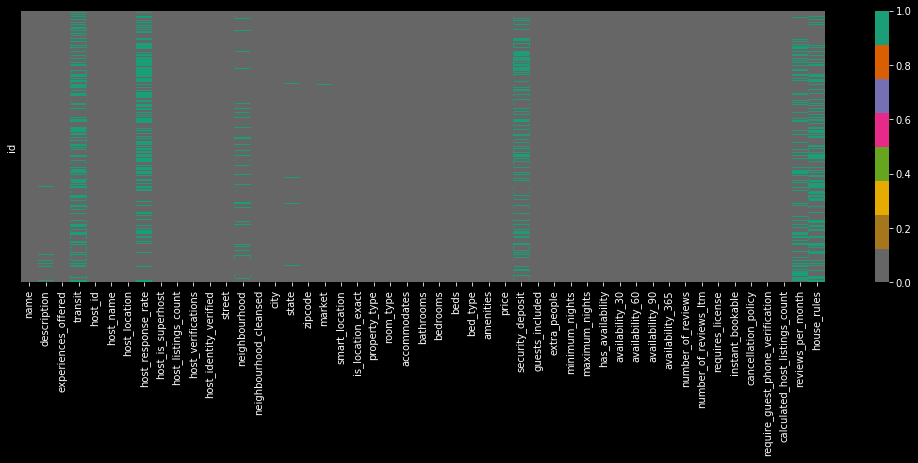

```python
plt.style.use ("dark_background")
plt.subplots(figsize=(18,5))
sns.heatmap(airbnb_cleaned_data.isnull(),yticklabels=False,cbar=True,
            cmap='Dark2_r')
```

# Interpretation

We are checking the null values in the airbnb dataset and find that many columns have NaN values.

```python
airbnb_cleaned_data=airbnb_cleaned_data[(airbnb_cleaned_data["state"]=="NSW")]
airbnb_cleaned_data.shape
```

```
(36757, 49)
```

# Interpretation

We are keeping rows which have value **`NSW`** for the **`state`** variable and output has **`36757 rows`** & **`49 columns**`.

```python
airbnb_cleaned_data['requires_license'] = airbnb_cleaned_data['requires_license'].map({'f': 0})
airbnb_cleaned_data['instant_bookable'] = airbnb_cleaned_data['instant_bookable'].map({'f': 0, 't': 1})
airbnb_cleaned_data['require_guest_phone_verification'] = airbnb_cleaned_data['require_guest_phone_verification'].map({'f': 0,'t': 1})
airbnb_cleaned_data['is_location_exact'] = airbnb_cleaned_data['is_location_exact'].map({'f': 0,'t': 1})
airbnb_cleaned_data['has_availability'] = airbnb_cleaned_data['has_availability'].map({'f': 0,'t': 1})
airbnb_cleaned_data['host_is_superhost'] = airbnb_cleaned_data['host_is_superhost'].replace('t', '1', regex=True)
airbnb_cleaned_data['host_is_superhost'] = airbnb_cleaned_data['host_is_superhost'].replace('f', '0', regex=True)
airbnb_cleaned_data['host_identity_verified'] = airbnb_cleaned_data['host_identity_verified'].replace('t', '1', regex=True)
airbnb_cleaned_data['host_identity_verified'] = airbnb_cleaned_data['host_identity_verified'].replace('f', '0', regex=True)
```

# Interpretation

We are mapping **`0`** to **`f(false)`** and **`1`** to **`t(true)`** values of variables **`requires_license`** ,**`instant_bookable`**, **`require_guest_phone_verification`** , **`is_location_exact`**, **`has_availability`**, **`host_is_superhost`** and **`host_identity_verified`** and converting them to **`int`** data types.

```python
airbnb_cleaned_data['bed_type'] = airbnb_cleaned_data['bed_type'].map({'Airbed' : 0, 'Couch' : 1,'Futon':2,'Pull-out Sofa':3,
                                                                       'Real Bed':4})
airbnb_cleaned_data['room_type'] = airbnb_cleaned_data['room_type'].map({'Entire home/apt' : 0,'Private room':1,'Shared room':2})

airbnb_cleaned_data['cancellation_policy'] = airbnb_cleaned_data['cancellation_policy'].map({'flexible': 0,
                                                                                            'luxury_moderate':1,
                                                                                            'luxury_no_refund':2,
                                                                                            'luxury_super_strict_125':3,
                                                                                            'luxury_super_strict_95':4,
                                                                                            'moderate':5,
                                                                                            'strict_14_with_grace_period':6,
                                                                                            'super_strict_30':7,
                                                                                            'super_strict_60':8})
```

# Interpretation

Mapping different **`bed_type`** , **`room_type`** and **`cancellation_policy`** varibales to numeric values.

| **`Variable`** | **`Value`** | **`Mapped Integer Value`** |
| --- | --- | --- |
| **`bed_type`** | Airbed | 0 |
|  | Couch | 1 |
|  | Fullton | 2 |
|  | Pull-out Sofa | 3 |
|  | Real Bed | 4 |
| **`room_type`** | Entire home/ap | 0 |
|  | Private room | 1 |
|  | Shared room | 2 |
| **`cancellation_policy`** | flexible | 0 |
|  | luxury_moderate | 1 |
|  | luxury_no_refund | 2 |
|  | luxury_super_strict_125 | 3 |
|  | luxury_super_strict_95 | 4 |
|  | moderate | 5 |
|  | strict_14_with_grace_period | 6 |
|  | super_strict_30 | 7 |
|  | super_strict_60 | 8 |

```
90 percentile value is 399.0
91 percentile value is 401.0
92 percentile value is 450.0
93 percentile value is 500.0
94 percentile value is 514.0
95 percentile value is 599.0
96 percentile value is 695.0
97 percentile value is 800.0
98 percentile value is 979.5199999999895
99 percentile value is 1277.2000000000116
100 percentile value is 36128.0
```

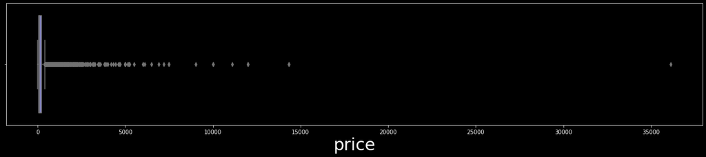

```python
airbnb_cleaned_data['price'] = airbnb_cleaned_data['price'].replace({'\$':'',',':''}, regex = True)
airbnb_cleaned_data['price']= pd.to_numeric(airbnb_cleaned_data['price'])
plt.style.use ("dark_background")
sns.boxplot(airbnb_cleaned_data['price'], palette = 'gist_stern_r')
plt.xlabel("price", size = 30)
plt.subplots_adjust(right=3)
for i in range(90,100 + 1):
    print(f'{i} percentile value is {np.percentile(airbnb_cleaned_data["price"], i)}')
airbnb_cleaned_data=airbnb_cleaned_data[(airbnb_cleaned_data.price>=0) & (airbnb_cleaned_data.price<=1300)]
```

# Interpretation

We have cleansed **`price`** column of the dataset, removing **$** symbol and converting the column type to **`int`**.

Above boxplot illustrates any **`outliers`** in the price column.

From the output ,we can see that **`99 percentile`** value is around **`1300`** ; so we have filtered the rows based up on the limit and removed outliers as well.

```
90 percentile value is 744.0000000000873
91 percentile value is 800.0
92 percentile value is 1000.0
93 percentile value is 1000.0
94 percentile value is 1000.0
95 percentile value is 1000.0
96 percentile value is 1000.0
97 percentile value is 1500.0
98 percentile value is 2000.0
99 percentile value is 2500.0
100 percentile value is 7164.0
```

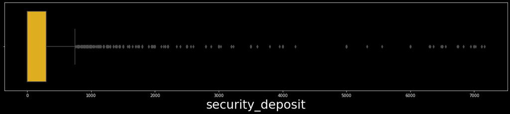

```python
airbnb_cleaned_data["security_deposit"]=airbnb_cleaned_data["security_deposit"].replace({'\$':'',',':''}, regex = True)
airbnb_cleaned_data["security_deposit"].isnull().sum()
airbnb_cleaned_data["security_deposit"].fillna("0", inplace = True)
airbnb_cleaned_data["security_deposit"]=pd.to_numeric(airbnb_cleaned_data["security_deposit"])
sns.boxplot(airbnb_cleaned_data["security_deposit"], palette = 'Wistia_r')
plt.xlabel("security_deposit", size =30)
plt.subplots_adjust(right=3)
for i in range(90,100 + 1):
    print(f'{i} percentile value is {np.percentile(airbnb_cleaned_data["security_deposit"], i)}')
airbnb_cleaned_data=airbnb_cleaned_data[(airbnb_cleaned_data.security_deposit>=0) & (airbnb_cleaned_data.security_deposit<=2500)]
```

# Interpretation

Secruity deposit column has most of the null values, we are replacing **`null_values`** with **`Zero`**. Boxplot depicts data has many outliers ( we need to remove these).

We can see that **`99 percentile`** for **`secruity_deposit`** has most of values under 2500 and only few are above this, so we are removing the outliers using this.

```
90 percentile value is 3.0
91 percentile value is 4.0
92 percentile value is 4.0
93 percentile value is 4.0
94 percentile value is 4.0
95 percentile value is 4.0
96 percentile value is 4.0
97 percentile value is 5.0
98 percentile value is 6.0
99 percentile value is 7.0
100 percentile value is 16.0
```

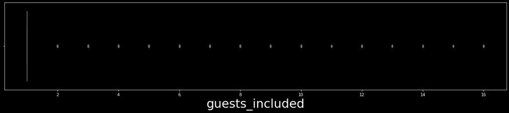

```python
sns.boxplot(airbnb_cleaned_data["guests_included"])
plt.xlabel("guests_included", size =30)
plt.subplots_adjust(right=3)
for i in range(90,100 + 1):
    print(f'{i} percentile value is {np.percentile(airbnb_cleaned_data["guests_included"], i)}')
```

# Interpretation

```
90 percentile value is 39.0
91 percentile value is 40.0
92 percentile value is 44.0
93 percentile value is 50.0
94 percentile value is 50.0
95 percentile value is 50.0
96 percentile value is 50.0
97 percentile value is 50.0
98 percentile value is 70.0
99 percentile value is 100.0
100 percentile value is 429.0
```

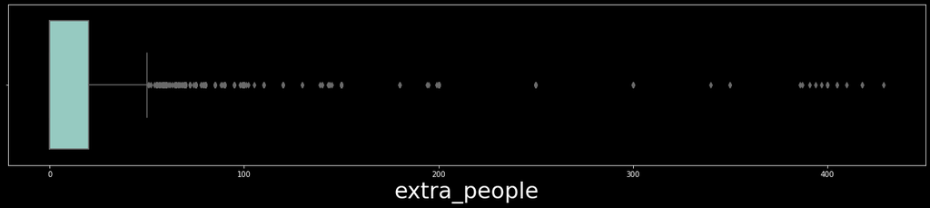

```python
airbnb_cleaned_data["extra_people"]=airbnb_cleaned_data["extra_people"].replace({'\$':'',',':''}, regex = True)
airbnb_cleaned_data["extra_people"]=pd.to_numeric(airbnb_cleaned_data["extra_people"])
sns.boxplot(airbnb_cleaned_data["extra_people"])
plt.xlabel("extra_people", size =30)
plt.subplots_adjust(right=3)
for i in range(90,100+1):
    print(f'{i} percentile value is {np.percentile(airbnb_cleaned_data["extra_people"],i)}')
airbnb_cleaned_data=airbnb_cleaned_data[(airbnb_cleaned_data.extra_people>=0) & (airbnb_cleaned_data.extra_people<=100)]
```

# Interpretation

As we can see most of the data points have less than 100 dollars for one **`extra person`**,so we removed the data points above 100 dollars as outliers.

```
0 percentile value is 1.0
10 percentile value is 14.0
20 percentile value is 25.0
30 percentile value is 38.0
40 percentile value is 300.0
50 percentile value is 1125.0
60 percentile value is 1125.0
70 percentile value is 1125.0
80 percentile value is 1125.0
90 percentile value is 1125.0
100 percentile value is 10000.0
```

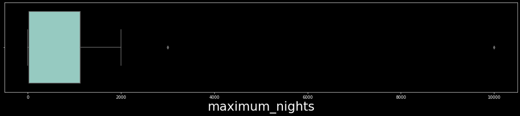

```python
sns.boxplot(airbnb_cleaned_data["maximum_nights"])
plt.xlabel("maximum_nights", size =30)
plt.subplots_adjust(right=3)
for i in range(0,100 + 10,10):
    print(f'{i} percentile value is {np.percentile(airbnb_cleaned_data["maximum_nights"], i)}')
airbnb_cleaned_data=airbnb_cleaned_data[(airbnb_cleaned_data.maximum_nights>=1) & (airbnb_cleaned_data.maximum_nights<=1125)]
```

# Interpretation

Above code checks the column **`maximum_nights`**, we are setting the points range between 1 and 1125 as other data points are outliers and removed those rows.

```
90 percentile value is 7.0
91 percentile value is 7.0
92 percentile value is 9.0
93 percentile value is 10.0
94 percentile value is 14.0
95 percentile value is 14.0
96 percentile value is 14.0
97 percentile value is 21.0
98 percentile value is 30.0
99 percentile value is 50.0
100 percentile value is 1000.0
```

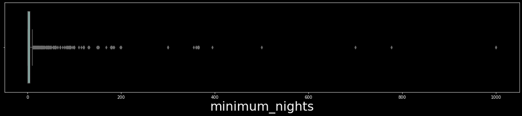

```python
sns.boxplot(airbnb_cleaned_data["minimum_nights"])
plt.xlabel("minimum_nights", size =30)
plt.subplots_adjust(right=3)
for i in range(90,100 + 1):
    print(f'{i} percentile value is {np.percentile(airbnb_cleaned_data["minimum_nights"], i)}')
airbnb_cleaned_data=airbnb_cleaned_data[(airbnb_cleaned_data.minimum_nights>=1) & (airbnb_cleaned_data.minimum_nights<=50)]
```

# Interpretation

Above boxplot shows the data spread in **`minimum_nights`** column and find that till **`99 percentile`** data spread is good and we are keeping value till this only.

```python
print("Percentile for the column availability_30",np.percentile(airbnb_cleaned_data['availability_30'],100))
print("Percentile for the column availability_60",np.percentile(airbnb_cleaned_data['availability_60'],100))
print("Percentile for the column availability_365",np.percentile(airbnb_cleaned_data['availability_365'],100))
```

```
Percentile for the column availability_30 30.0
Percentile for the column availability_60 60.0
Percentile for the column availability_365 365.0
```

# Interpretation

We are checking **`100`** percentile for the columns **`availability_30`** , **`availability_60`** & **`availability_365`** and find that values for 100 percentile is 30,60 and 365 for respective columns and we are good with these columns.

```
90 percentile value is 41.0
91 percentile value is 46.0
92 percentile value is 51.0
93 percentile value is 58.0
94 percentile value is 65.0
95 percentile value is 75.0
96 percentile value is 87.0
97 percentile value is 102.37000000000262
98 percentile value is 125.58000000000175
99 percentile value is 165.0
100 percentile value is 576.0
314.75800000000163
```

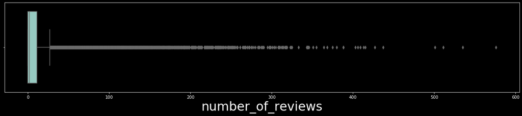

```python
sns.boxplot(airbnb_cleaned_data['number_of_reviews'])
plt.xlabel("number_of_reviews", size =30)
plt.subplots_adjust(right=3)
for i in range(90,100 +1):
    print(f'{i} percentile value is {np.percentile(airbnb_cleaned_data["number_of_reviews"], i)}')
print(np.percentile(airbnb_cleaned_data["number_of_reviews"],99.9))
airbnb_cleaned_data=airbnb_cleaned_data[(airbnb_cleaned_data.number_of_reviews >=0)&(airbnb_cleaned_data.number_of_reviews <=314.758)]
```

# Interpretation

We are checking the data spread in **`number_of_reviews`** and found out that till 99.9 percentile data spread is good.

```python
airbnb_cleaned_data=airbnb_cleaned_data[~airbnb_cleaned_data.host_name.str.contains('\ê', na=False)]
airbnb_cleaned_data=airbnb_cleaned_data[~airbnb_cleaned_data.host_name.str.contains('(Email hidden by Airbnb)', na=False)]
airbnb_cleaned_data=airbnb_cleaned_data[~airbnb_cleaned_data.host_name.str.contains('(Website hidden by Airbnb)', na=False)]
airbnb_cleaned_data=airbnb_cleaned_data[~airbnb_cleaned_data.host_name.str.contains('(Phone Number hidden by Airbnb)', na=False)]
airbnb_cleaned_data=airbnb_cleaned_data[~airbnb_cleaned_data.host_name.str.contains(',', na=False)]
airbnb_cleaned_data=airbnb_cleaned_data[~airbnb_cleaned_data.host_name.str.contains('\∏', na=False)]
airbnb_cleaned_data=airbnb_cleaned_data[~airbnb_cleaned_data.host_name.str.contains('\Ä', na=False)]
airbnb_cleaned_data=airbnb_cleaned_data[~airbnb_cleaned_data.host_name.str.contains('\ú', na=False)]
airbnb_cleaned_data=airbnb_cleaned_data[~airbnb_cleaned_data.host_name.str.contains('\‰', na=False)]
airbnb_cleaned_data=airbnb_cleaned_data[~airbnb_cleaned_data.host_name.str.contains('\Ë', na=False)]
airbnb_cleaned_data=airbnb_cleaned_data[~airbnb_cleaned_data.host_name.str.contains('\≥', na=False)]
airbnb_cleaned_data=airbnb_cleaned_data[~airbnb_cleaned_data.host_name.str.contains('\∑', na=False)]
airbnb_cleaned_data=airbnb_cleaned_data[~airbnb_cleaned_data.host_name.str.contains('\º', na=False)]
airbnb_cleaned_data=airbnb_cleaned_data[~airbnb_cleaned_data.host_name.str.contains('\ü', na=False)]
airbnb_cleaned_data=airbnb_cleaned_data[~airbnb_cleaned_data.host_name.str.contains('\π', na=False)]
airbnb_cleaned_data=airbnb_cleaned_data[~airbnb_cleaned_data.host_name.str.contains('\ô', na=False)]
airbnb_cleaned_data=airbnb_cleaned_data[~airbnb_cleaned_data.host_name.str.contains('√', na=False)]
airbnb_cleaned_data=airbnb_cleaned_data[~airbnb_cleaned_data.host_name.str.contains('\Â', na=False)]
airbnb_cleaned_data=airbnb_cleaned_data[~airbnb_cleaned_data.host_name.str.contains('\Ø', na=False)]
airbnb_cleaned_data=airbnb_cleaned_data[~airbnb_cleaned_data.host_name.str.contains('\Á', na=False)]
airbnb_cleaned_data=airbnb_cleaned_data[~airbnb_cleaned_data.host_name.str.contains('\Å', na=False)]
airbnb_cleaned_data= airbnb_cleaned_data.dropna(axis=0, subset=['host_name'])
airbnb_cleaned_data=airbnb_cleaned_data[~airbnb_cleaned_data.host_location.str.contains('\Ö', na=False)]
airbnb_cleaned_data=airbnb_cleaned_data[~airbnb_cleaned_data.host_location.str.contains('\√', na=False)]
airbnb_cleaned_data= airbnb_cleaned_data.dropna(axis=0, subset=['host_location'])
```

# Interpretation

We are removing the **`special characters`** or any other value apart from a name from the **`host_name`** and **`host_location`** variable.

```python
airbnb_cleaned_data.host_response_rate.fillna(0 , inplace=True)
airbnb_cleaned_data.reviews_per_month.fillna(0 , inplace=True)
```

# Interpretation

We are mapping the **`null values`** of the **`host_response_rate`** and **`reviews_per_month`** varibales with value 0 because we cannot drop the NaN values for these variables.

```python
airbnb_cleaned_data['host_response_rate'] = airbnb_cleaned_data['host_response_rate'].replace('%', '', regex=True)
```

# Interpretation

We are removing the **`%`** sign from the **`host_response_rate`** to use it for analysis and plotting.

```python
airbnb_cleaned_data['host_verifications'] = airbnb_cleaned_data['host_verifications'].str.count(',') + 1
```

```python
airbnb_cleaned_data=airbnb_cleaned_data[~airbnb_cleaned_data.street.str.contains('\†', na=False)]
airbnb_cleaned_data=airbnb_cleaned_data[~airbnb_cleaned_data.street.str.contains('\Ä', na=False)]
airbnb_cleaned_data=airbnb_cleaned_data[~airbnb_cleaned_data.street.str.contains('\Â', na=False)]
airbnb_cleaned_data=airbnb_cleaned_data[~airbnb_cleaned_data.street.str.contains('\Ê', na=False)]
airbnb_cleaned_data=airbnb_cleaned_data[~airbnb_cleaned_data.city.str.contains('\†', na=False)]
airbnb_cleaned_data=airbnb_cleaned_data[~airbnb_cleaned_data.city.str.contains('\Ä', na=False)]
airbnb_cleaned_data=airbnb_cleaned_data[~airbnb_cleaned_data.city.str.contains('\Â', na=False)]
airbnb_cleaned_data=airbnb_cleaned_data[~airbnb_cleaned_data.city.str.contains('\Ê', na=False)]
```

# Interpretation

We are removing the special characters from the variables - **`street`** & **`city`**.

```python
airbnb_cleaned_data['amenities'] = airbnb_cleaned_data.amenities.map(lambda x: [i.strip() for i in x.split(",")])
airbnb_cleaned_data['amenities'].head()
```

```
id
11156    [{TV, Kitchen, Elevator, "Buzzer/wireless inte...
14250    [{TV, Wifi, "Air conditioning", Kitchen, "Pets...
20865    [{TV, Internet, Wifi, "Air conditioning", Kitc...
26174    [{TV, Wifi, Kitchen, "Free street parking", He...
38073    [{TV, "Cable TV", Wifi, "Air conditioning", Po...
Name: amenities, dtype: object
```

# Interpretation

For Amenities, we are splitting each amenity with a comma so that we can count the total number of amenities for each row.

```python
airbnb_cleaned_data['amenities_count']= airbnb_cleaned_data['amenities'].apply(len)
print(airbnb_cleaned_data['amenities_count'].head())
```

```
id
11156    23
14250    33
20865    23
26174    28
38073    23
Name: amenities_count, dtype: int64
```

# Interpretation

After splitting the amenities from the list, we are printing the length of each list for the variable amenities. We have created a new column named **`amenities_count`** that is printing the length of each row in the column amenities.

```python
print (airbnb_cleaned_data.shape)
airbnb_cleaned_data.head()
```

```
(35485, 50)
```

| id | name | description | experiences_offered | transit | host_id | host_name | host_location | host_response_rate | host_is_superhost | host_listings_count | ... | number_of_reviews | number_of_reviews_ltm | requires_license | instant_bookable | cancellation_policy | require_guest_phone_verification | calculated_host_listings_count | reviews_per_month | house_rules | amenities_count |
| --- | --- | --- | --- | --- | --- | --- | --- | --- | --- | --- | --- | --- | --- | --- | --- | --- | --- | --- | --- | --- | --- |
| 11156 | An Oasis in the City | Very central to the city which can be reached ... | none | It is 7 minutes walk to the Kings Cross.train ... | 40855 | Colleen | Potts Point, New South Wales, Australia | 50 | 0 | 1.000 | ... | 185 | 10 | 0 | 0 | 5.000 | 0 | 1 | 1.580 | Be considerate. No showering after 2330h. | 23 |
| 14250 | Manly Harbour House | Beautifully renovated, spacious and quiet, our... | none | Balgowlah - Manly bus # 131 or #132 (Bus stop... | 55948 | Heidi | Sydney, New South Wales, Australia | 100 | 0 | 2.000 | ... | 2 | 1 | 0 | 0 | 6.000 | 0 | 2 | 0.050 | Standard Terms and Conditions of Temporary Hol... | 33 |
| 20865 | 3 BED HOUSE + 1 BED STUDIO Balmain | Hi! We are a married professional couple with ... | none | Balmain is well serviced by buses (from Darlin... | 64282 | Fiona | Sydney, New South Wales, Australia | 100 | 1 | 2.000 | ... | 16 | 1 | 0 | 0 | 6.000 | 1 | 1 | 0.170 | PLEASE ENJOY YOURSELVES WITHOUT MAKING TOO MUC... | 23 |
| 26174 | COZY PRIVATE ROOM, GREAT LOCATION! | Double bed in decent sized bedroom, in two bed... | none | NaN | 110561 | Amanda | Sydney, New South Wales, Australia | 100 | 0 | 1.000 | ... | 45 | 7 | 0 | 0 | 5.000 | 0 | 1 | 0.450 | Need to be quiet after 10.30pm No Smoking Clea... | 28 |
| 38073 | Modern apartment with pool and parking | Welcome to my sanctuary - a bright, comfortabl... | none | OPAL CARDS is the easiest and cheapest way to ... | 103476 | Prasanna | Warrawong, New South Wales, Australia | 100 | 0 | 2.000 | ... | 63 | 0 | 0 | 0 | 6.000 | 1 | 2 | 0.600 | House Rules: •Smoking permitted outside only w... | 23 |

5 rows × 50 columns

# Interpretation

Above output display values after data cleaning and it has **`35485 rows`** & **`50 columns`**.

# **`Starting with the Data Analysis and Visualization`**

```python
all_house_rules = ' '.join(airbnb_cleaned_data['house_rules'].iloc[0:12].str.lower())
```

# Interpretation

Here, we are making use of the column `house_rules` from our dataframe `airbnb_cleaned_data` to perform a **`word cloud analysis`** on this column since house_rules contains text regarding the rules that tenants should keep in mind while booking a particular listing.

```python
from nltk.corpus import stopwords
stop_words = set(stopwords.words("english"))
stop_words.add ('please')
stop_words.add ('apartment')
print(stop_words)
```

```
{'all', 'was', 'needn', 'please', 'couldn', 'by', 'these', 've', 'through', 'don', 'about', 'for', 'just', 'you', 'aren', 'itself', 'been', "you'd", 'yourselves', 'what', 'a', "mightn't", 'be', 'and', 'off', 'of', 'll', 'now', 'will', 'before', 'y', 'down', 'it', "haven't", 'yours', 'o', "shouldn't"…
```

# Interpretation

Here, we are have imported `stopwords` from `nltk.corpus`. After the import we stored all the english stopwords in `stop_words`. This list is a pre-defined list of stopwords in NLTK. After that, we are adding some stopwords from the column `house_rules` and printed the appended list out as output.

```python
wordcloud = WordCloud(stopwords=stop_words,
                      background_color="grey",
                      max_words=10000).generate(all_house_rules)
```

# Interpretation

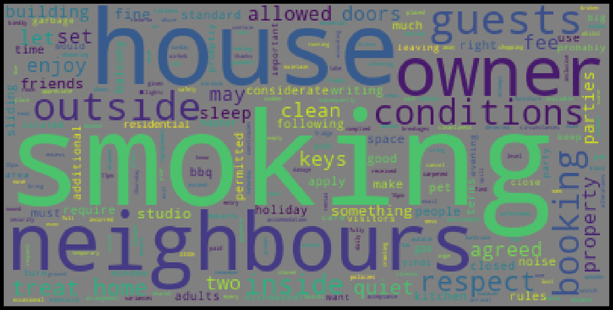

```python
rcParams['figure.figsize'] = 20, 20
plt.imshow(wordcloud)
plt.axis("off")
plt.show()
```

# Interpretation

We have printed the **`WordCloud`** for the column `house_rules` for limited number of rows and as can be seen from the WordCloud, there are multiple words that occur frequently in our text, out of which **smoking** is one which denotes that most of the listings have a common house rule that says "**Smoking not allowed**"

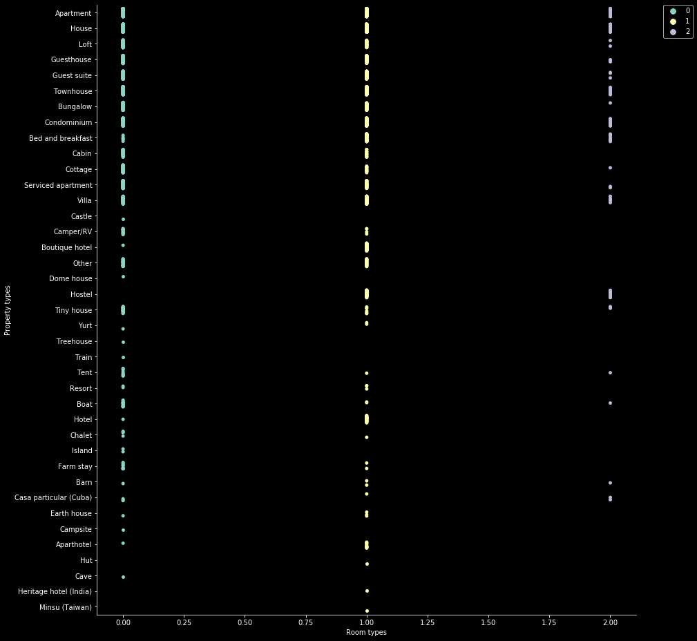

```python
sns.catplot(x='room_type', y='property_type',
            data=airbnb_cleaned_data,jitter='0.25',
            height=13,hue="room_type")
plt.xlabel("Room types")
plt.ylabel("Property types")
plt.legend(bbox_to_anchor=(1.05, 1), loc='upper left', borderaxespad=0.)
plt.show()
```

# Interpretation

Above plot shows the comparison between different types of **`property`** and **`room types`**. Here, we used numeric values to depict the **`room type`** such as **`0`** stands for Entire house or apartment , **`1`** stands for **`Private room`** and **`2`** stands for **`Shared room`**.

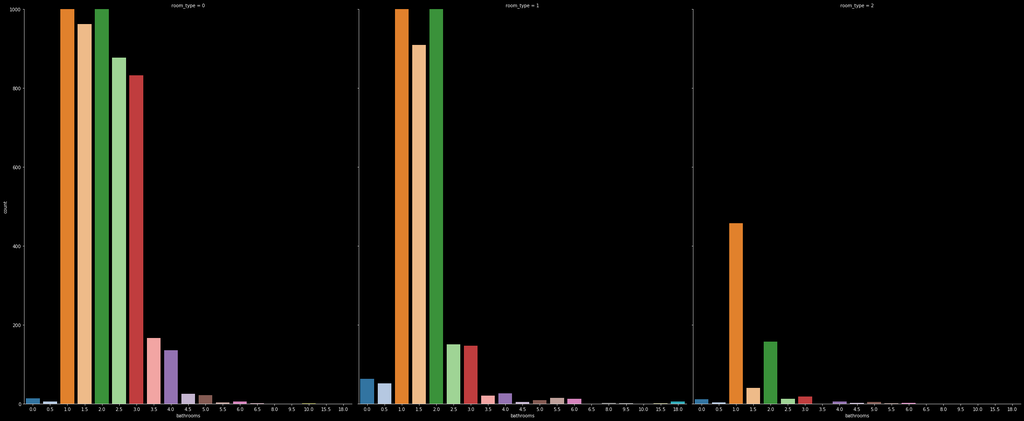

```python
sns.factorplot("bathrooms", col="room_type", col_wrap=4,
                data=airbnb_cleaned_data,
                kind="count", height=13, aspect=.8,
                palette='tab20')
plt.ylim(0,1000)
plt.show()
```

# Interpretation

We are checking the number of **`bathrooms`** in each category of the **`room`** types. We conclude that the **`entire house`** has most number of bathrooms. All of the three types are mostly providing 1 & 2 bathrooms. (0 <- Entire house, 1 <- Private Room , 2 <- Shared Room)

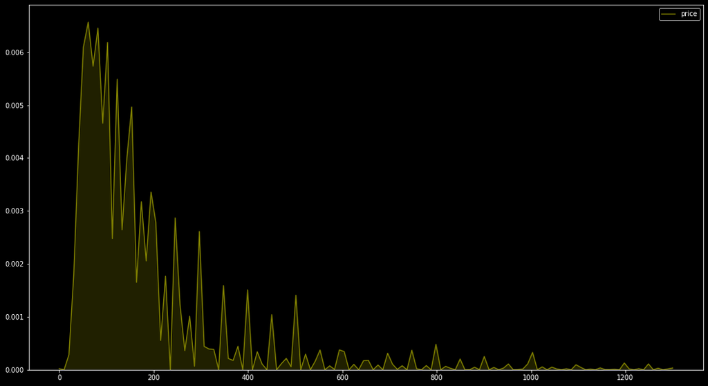

```python
plt.figure(figsize=(18,10))
sns.kdeplot(airbnb_cleaned_data['price'], shade=True, bw=.05, color="olive")
```

# Interpretation

```python
values = ','.join(str(v) for v in airbnb_cleaned_data.transit)
words = values.split()
resulting_count = collections.Counter(words).most_common(100)
```

```python
transit_1 = pd.DataFrame(resulting_count)
transit_1.columns = ['a', 'b']
```

```python
transit_updated=transit_1[(transit_1['a']=="train") | (transit_1["a"]=="bus") | (transit_1["a"]=="walk") | (transit_1["a"]=="station") | (transit_1["a"]=="buses") | (transit_1["a"]=="Station") | (transit_1["a"]=="walking") | (transit_1["a"]=="ferry")  | (transit_1["a"]=="car") | (transit_1["a"]=="Bus") | (transit_1["a"]=="Train") | (transit_1["a"]=="Uber")]
```

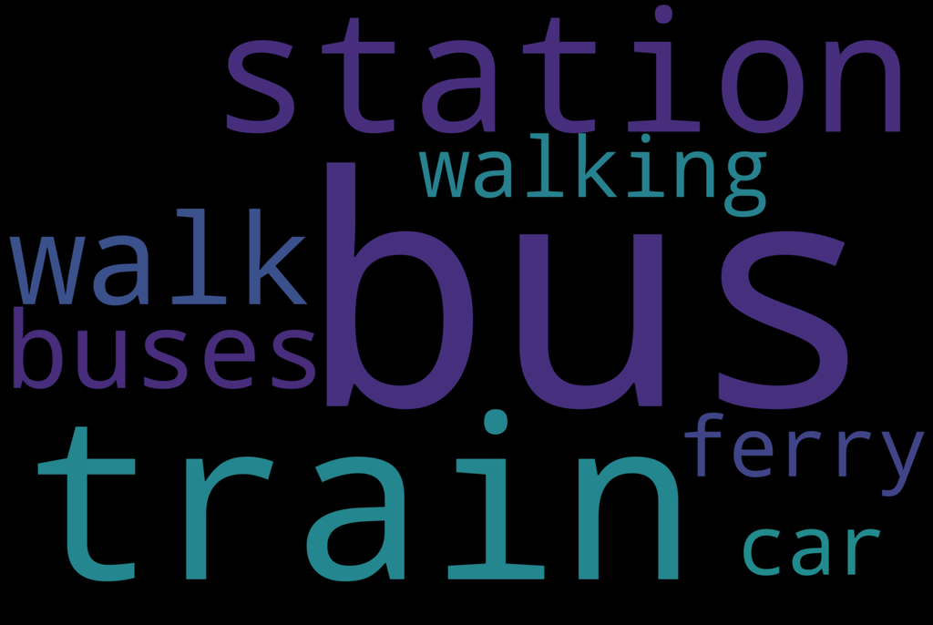

```python
from wordcloud import WordCloud, STOPWORDS
STOPWORDS.add ("dtype")
STOPWORDS.add ("Name")
STOPWORDS.add ("object")
import matplotlib.pyplot as plt
text = transit_updated.a
wordcloud = WordCloud(
    width = 3000,
    height = 2000,
    background_color = 'black',
    stopwords = STOPWORDS).generate(str(text))
fig = plt.figure(
    figsize = (20, 20),
    facecolor = 'k',
    edgecolor = 'k')
plt.imshow(wordcloud, interpolation = 'bilinear')
plt.axis('off')
plt.tight_layout(pad=0)
plt.show()
```

# Interpretation

```python
airbnb_corr=airbnb_cleaned_data[["price","room_type","bed_type","security_deposit","is_location_exact","availability_30","availability_60","availability_90","availability_365","number_of_reviews_ltm"]]
airbnb_corr.corr().iplot(kind='heatmap',colorscale="Blues",title="Correlation matrix : Airbnb dataset")
```

[interactive chart not shown]

# Interpretation

We are checking the **`correlation`** of various variables of airbnb dataset **`price , room_type , bed_type ,security_deposit, is_location_exact, availability_30,availability_60,availability_90, availability_365, number_of_reviews_ltm`** and come up with below conclusions :-

1) **`Price`** is highly related with **`security_deposit`** and least related with the type of room.

2) Type of the room is weakly related with every other variable choosen for correlation matrix.

3) Location is exact or not is not related /depends upon price, secruity deposit , type of room or bed type.

```python
bifurcate_superhost = pd.crosstab(index=airbnb_cleaned_data["host_is_superhost"],columns=airbnb_cleaned_data["host_is_superhost"])
```

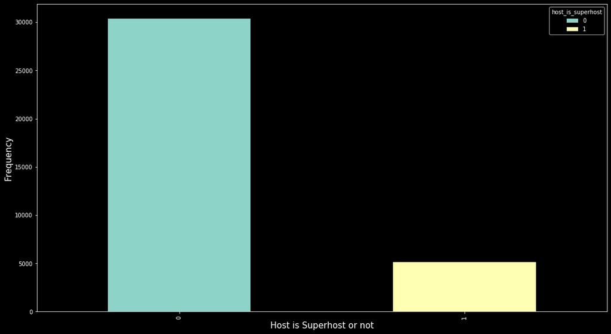

```python
bifurcate_superhost.plot(kind="bar", figsize=(18,10),stacked=True)
plt.tick_params(labelsize=10)
plt.xlabel("Host is Superhost or not" ,fontsize =15)
plt.ylabel("Frequency", fontsize=15)
plt.show()
```

# Interpretation

From above plot we can conlcude that our dataset has **`30373 non super host`** and **`5112 super hosts`**.

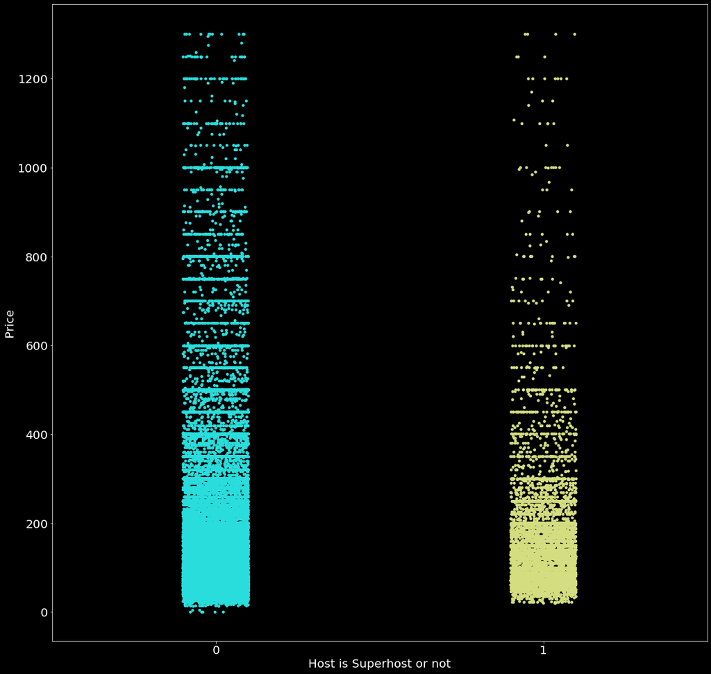

```python
sns.stripplot(x='host_is_superhost',y='price',data=airbnb_cleaned_data,palette='rainbow',jitter=0.1)
plt.xlabel("Host is Superhost or not", fontsize=20)
plt.tick_params(labelsize=20)
plt.ylabel ("Price",fontsize=20)
plt.show()
```

# Interpretation

We are checking the **`price`** of the listing depends upon whether **`host is a superhost or not`**. We conclude that the most listings have price around 100- 300 dollars whose host is not a superhost and equally spread till 1200 dollars whereas superhost have price most of listings have price between 100-200 dollars and spreaded values till 1200 dollars.

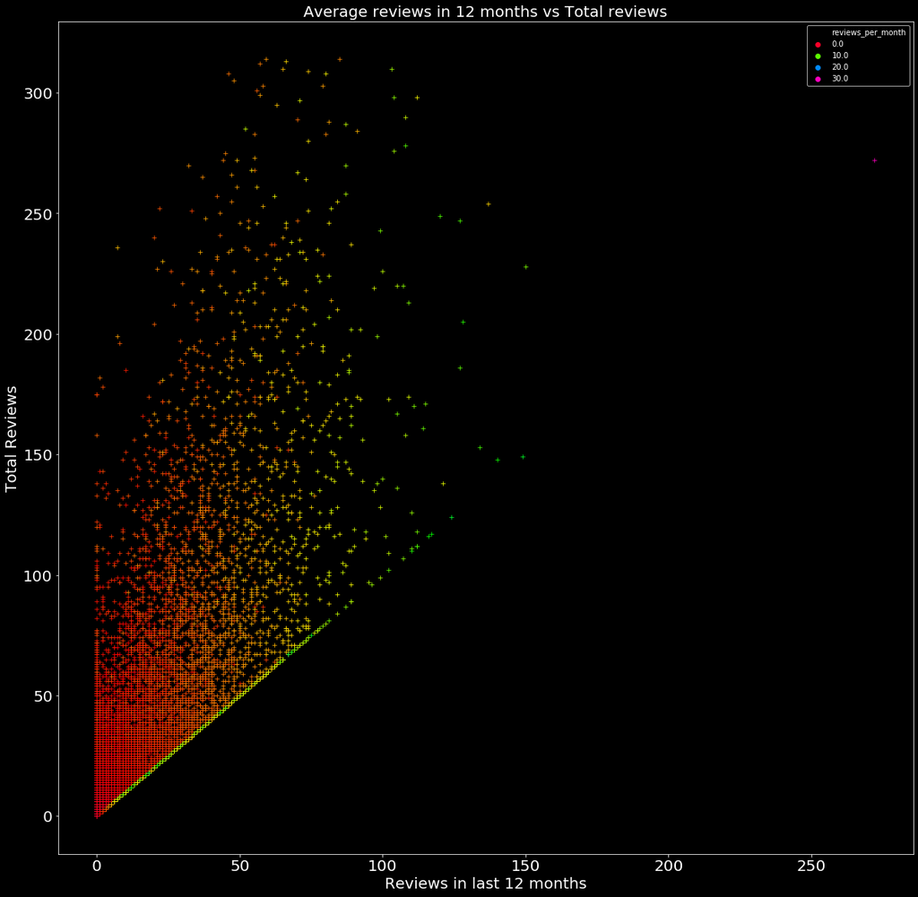

```python
plt.style.use ("dark_background")
plt.figure(figsize=(20, 20))
sns.scatterplot(x="number_of_reviews_ltm", y="number_of_reviews", data=airbnb_cleaned_data,
                hue = "reviews_per_month", marker = '+', markers= 50, palette = 'gist_rainbow')
plt.title ("Average reviews in 12 months vs Total reviews", fontsize = 20)
plt.xlabel ("Reviews in last 12 months", fontsize = 20)
plt.tick_params(labelsize = 20)
plt.ylabel ("Total Reviews", fontsize = 20)
```

# Interpretation

This scatter plot signifies the relationship between the columns **`number_of_reviews`** and **`number of reviews_ltm`** for all the respective listings along with the category **`reviews_per_month`**. As we can see that the total number of reviews are nicely spread and goes in relation with the Average number of reviews per month. We can clonclude that most the hosts have provided reviews for the listings.

```python
import plotly.express as px
fig = px.scatter_3d(airbnb_cleaned_data, x='availability_30',
                    y='availability_60', z='availability_90',
                    color='room_type')
fig.show()
```

[interactive chart not shown]

# Interpretation

After plotting the 3D Scatterplot, we discover that in the room availabilities as per **`availability_30`** , **`availability_60`** , **`availability_90`** , the most common **`room_type`** is 0 which is 'Entire Home / Apartment', is the most booked type of room and is also available in the maximum cases. This is followed by **`room_type`** = 1, which is 'Private Room' and lastly, 'Shared Room', which is the least booked.

```python
neighb = airbnb_cleaned_data.groupby('neighbourhood').mean()[['price']]
```

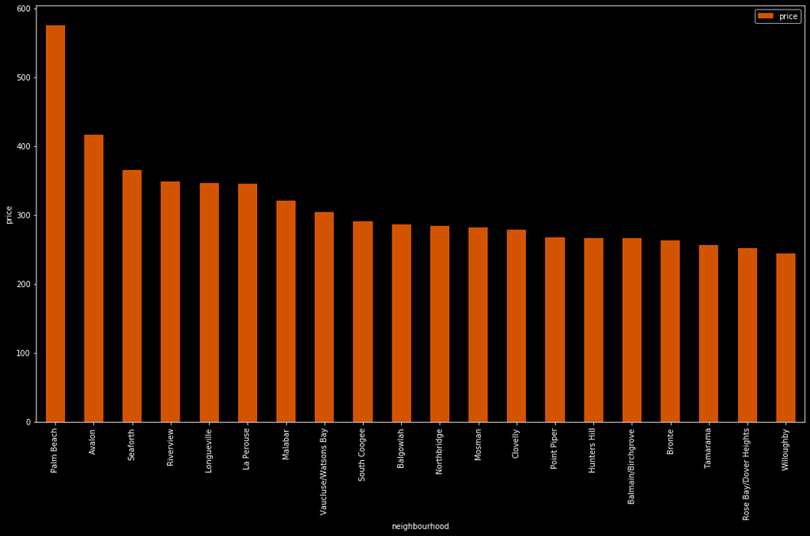

```python
sorted_data=neighb.sort_values('price', axis=0, ascending=False, inplace=False, kind='quicksort', na_position='last')
plt.style.use("dark_background")
top20=sorted_data.iloc[:20]
top20.plot(kind='bar',figsize=(18,10),color='#D35400')
plt.xlabel("neighbourhood")
plt.ylabel("price")
```

# Interpretation

As per the above graph, we are displaying the top 20 neighbourhoods with the highest price.

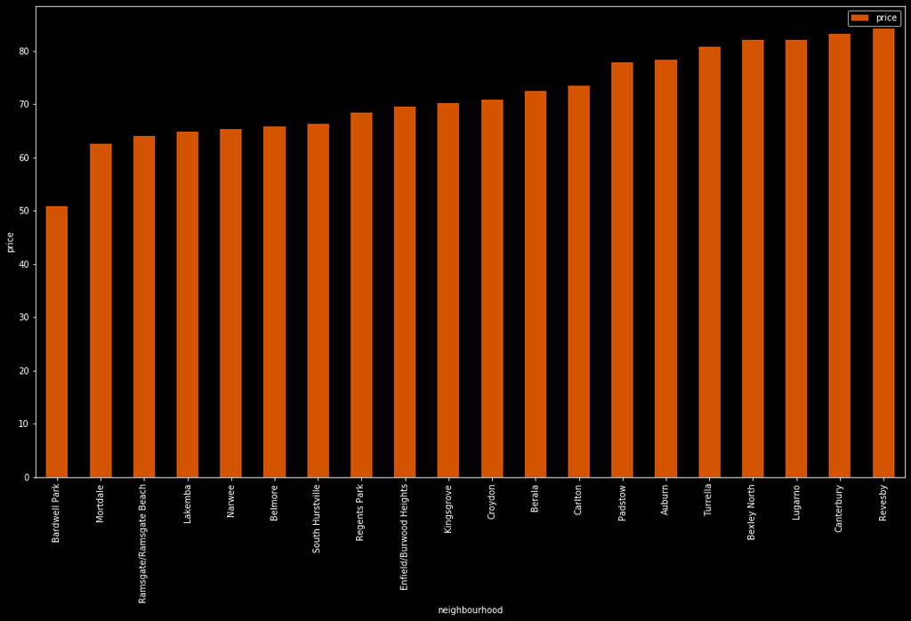

```python
sort_asc=neighb.sort_values('price', axis=0, ascending=True, inplace=False, kind='quicksort', na_position='last')
least20=sort_asc.iloc[:20]
plt.style.use("dark_background")
least20.plot(kind='bar',figsize=(18,10),color='#D35400')
plt.xlabel("neighbourhood")
plt.ylabel("price")
```

# Interpretation

As per the above graph, we are displaying the the last 20 neighbourhoods with price range.

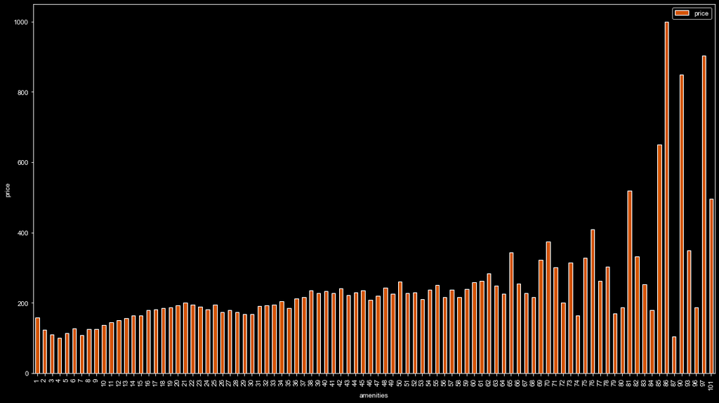

```python
amen=airbnb_cleaned_data.groupby('amenities_count').mean()[['price']]
sns.set_style("ticks")
plt.style.use ("dark_background")
amen.plot(kind='bar',figsize=(18,10),color='#D35400')
plt.xlabel("amenities")
plt.ylabel("price")
```

# Interpretation

As per the above graph, we are displaying the **`price variation`** vs the **`amenities count`**. As the number of amenities increase, the price also increase and there is a positive relation between the two.

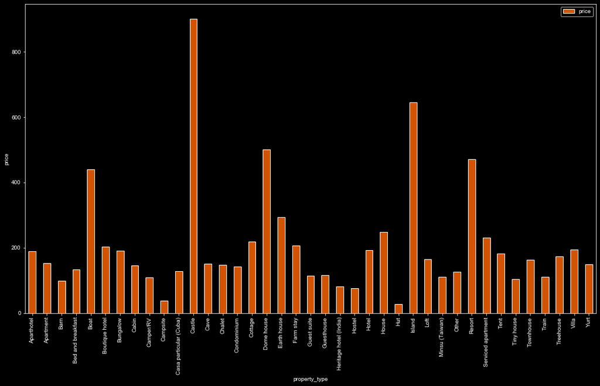

```python
prop_type=airbnb_cleaned_data.groupby('property_type').mean()[['price']]
sns.set_style("ticks")
plt.style.use ("dark_background")
prop_type.plot(kind='bar',figsize=(18,10),color='#D35400')
plt.xlabel("property_type")
plt.ylabel("price")
```

# Interpretation

We are displaying as to what kind of property is with the highest price  
From the above graph, we can conclude that the **`property type Castle`** has the `highest price`.

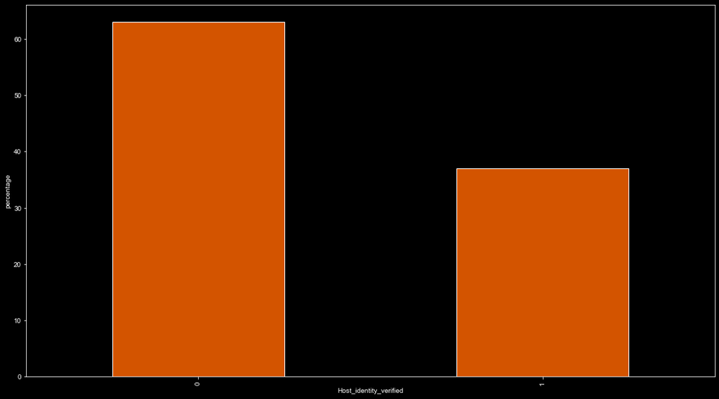

```python
percentage=airbnb_cleaned_data.host_identity_verified.value_counts()/airbnb_cleaned_data.shape[0]*100
plt.style.use ("dark_background")
percentage.plot(kind="bar",color='#D35400', figsize = (18,10))
plt.xlabel("Host_identity_verified")
plt.ylabel("percentage")
```

# Interpretation

From the above graph, we can conclude that **`just over 60%`** of the hosts details are not verified by the Airbnb while the rest have been successfully verified by Airbnb.  
From this we can conclude that the host verification process is not good from Airbnb side and this can be considered as a flaw.

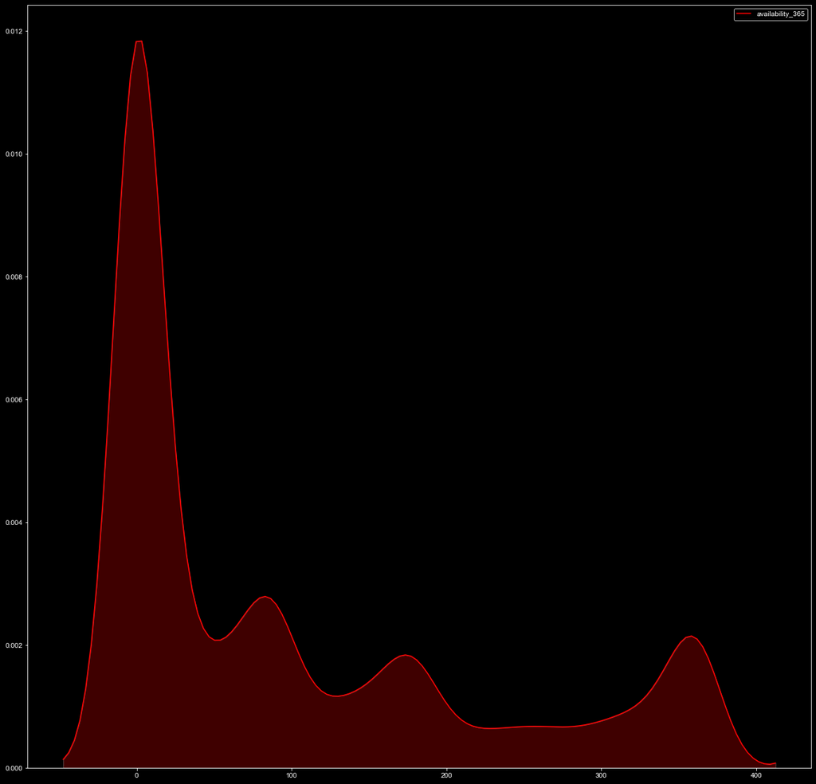

```python
plt.style.use ("dark_background")
sns.kdeplot(airbnb_cleaned_data.availability_365, shade=True, color="r")
```

# Interpretation

From the above graph, we can conclude that, **`in a year most of the accomodations are not available`** while very few are available all the 365 days in an year.

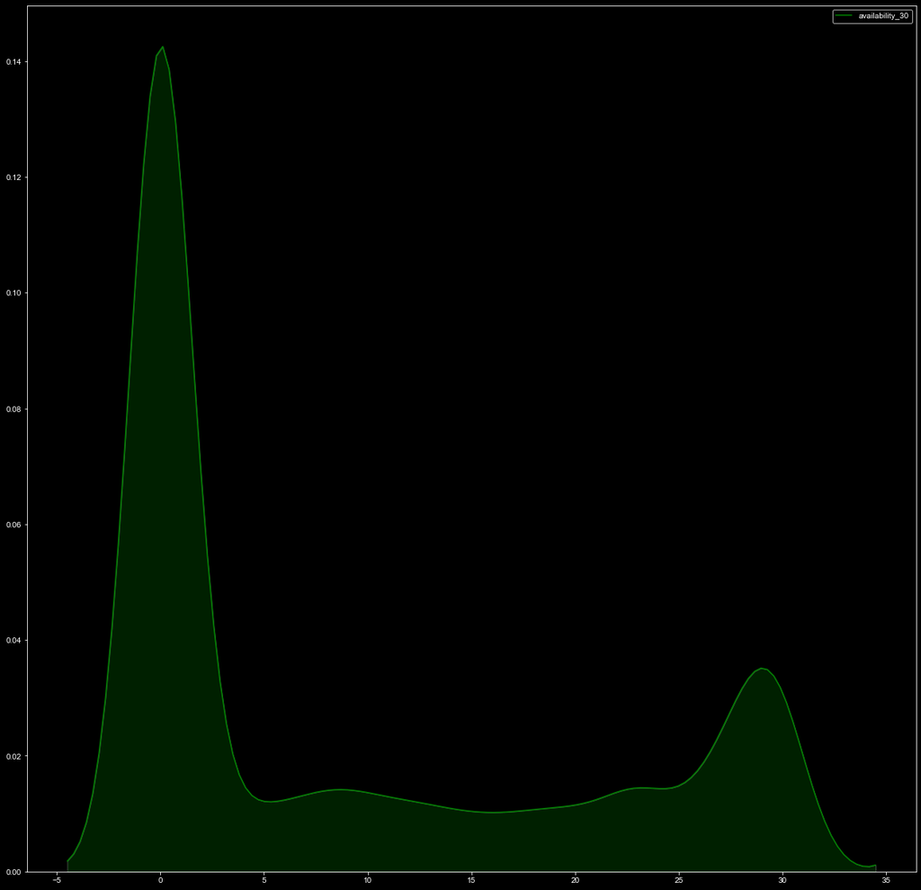

```python
plt.style.use ("dark_background")
sns.kdeplot(airbnb_cleaned_data.availability_30, shade=True, color="g")
```

# Interpretation

From the above graph, we can conclude that, in a 30 days period, most of the listings are not available for bookings.

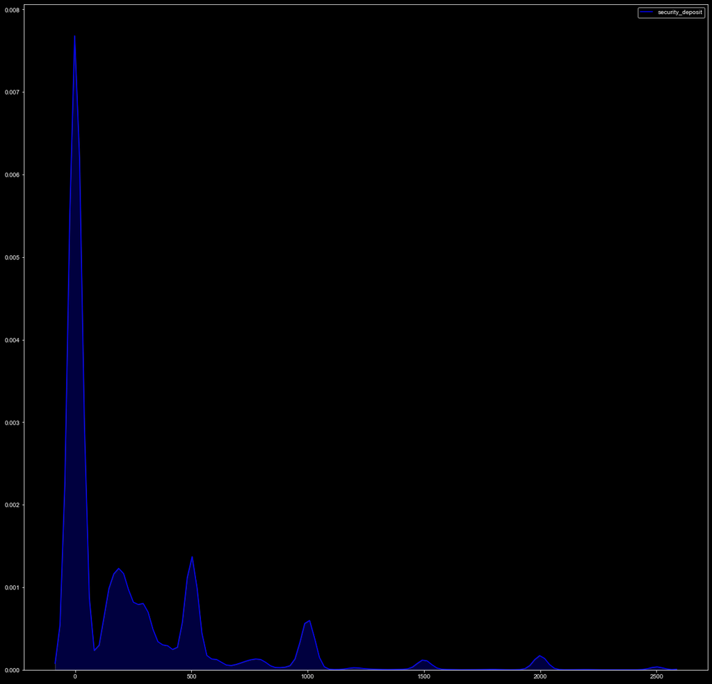

```python
plt.style.use ("dark_background")
sns.kdeplot(airbnb_cleaned_data.security_deposit, shade=True, color="b")
```

# Interpretation:

From the above graph, we can clonclude that, majority of the listings on airbnb do not ask for security deposit.

# Feature engineering for classification :

```python
print(f'{i} percentile value is {np.percentile(airbnb_cleaned_data["price"], 50)}')
print(f'{i} percentile value is {np.percentile(airbnb_cleaned_data["price"], 75)}')
```

```
100 percentile value is 125.0
100 percentile value is 200.0
```

# Interpretation

We are checking the **`50`** & **`75`** **`percentile`** of the **`price`** column and find that 50 percent of the lisitngs has price 125 dollars and 75 percent has price 200 dollars.

```python
def doubleData(x):
    if x<=125:
        return 0
    elif((x>125)&(x<=200)):
        return 1
    else:
        return 2
```

# Interpretation

We are classifying the price values on their percentile values:

1) **`Price`** equal or less than 125 dollars is kept as 0 (low).

2) **`Price`** between 125 and 200 dollars is classified as 1 (medium).

3) **`Price`** greatet than 200 is classified as 2 (high).

```python
airbnb_cleaned_data["price_class"] =airbnb_cleaned_data["price"].apply(doubleData)
```

# Interpretation

# `Logistic Regression on Price Class`

```python
airbnb_cleaned_data["bathrooms"].fillna(0,inplace=True)
airbnb_cleaned_data["bedrooms"].fillna(0,inplace=True)
airbnb_cleaned_data["cancellation_policy"].fillna(0,inplace=True)
airbnb_cleaned_data["beds"].replace("",np.nan,inplace=True)
airbnb_cleaned_data["beds"].fillna(0,inplace=True)
```

# Interpretation

We are filling 0 for the NaN values in the **`bathrooms, bedrooms,cancellation_policy`** columns and replcing the blank values in **`beds`** with NaN and then filling 0 for NaN values. (this is done for fitting th logistic regression)

```python
y=airbnb_cleaned_data["price_class"]
X=airbnb_cleaned_data.drop(["name","description","experiences_offered","transit","host_id","host_name","host_location","street","neighbourhood","neighbourhood_cleansed","city",
                            "street","state","zipcode","market","smart_location","property_type","amenities","price","price_class","house_rules"],axis=1)
```

# Interpretation

We are keeping **`price_class`** in the y array (this will be our prediction value) and dropping all the string columns from the dataset and assiging it to the array X.

```python
X_train,X_test,y_train,y_test=train_test_split(X,y, test_size=0.3)
```

# Interpretation

We are splitting the data in two array of test and train. We are splitting the data because first we will train our model and later test our model on test data to get the accuracy score of the model built.

```python
X_train= StandardScaler(with_mean=False).fit_transform(X_train)
X_test=StandardScaler(with_mean=False).fit_transform(X_test)
```

# Interpretation

We are standardising the X array to bring the data on to same scale.

```python
log_model=LogisticRegression()
log_model.fit(X_train,y_train)
```

```
LogisticRegression(C=1.0, class_weight=None, dual=False, fit_intercept=True,
                   intercept_scaling=1, l1_ratio=None, max_iter=100,
                   multi_class='warn', n_jobs=None, penalty='l2',
                   random_state=None, solver='warn', tol=0.0001, verbose=0,
                   warm_start=False)
```

# Interpretation

We are fitting **`logistic regression`** to the training dataset to predict the price_class variable values.

```python
print("Score of the Logistic Model is : ",log_model.score(X_test,y_test))
```

```
Score of the Logistic Model is :  0.7040202893105392
```

# `KNN Model on Price Class`

```python
knn_model = KNeighborsClassifier(n_neighbors=1)
knn_model.fit(X_train, y_train)
knn_model.fit(X_train,y_train)
y_pred=knn_model.predict(X_test)
```

# Interpretation

We are fitting the **`Knn`** model for the trainig dataset and prediciting the **`price_class`** in y array.

```python
print("Accuracy of KNN model:", accuracy_score(y_test,y_pred))
```

```
Accuracy of KNN model: 0.643340221679504
```

# Interpretation

We are checking the accuracy score of the **`Knn model`**.

# Comparing the Logistic & KNN models for Price Class

We find that the score of **`Logistic model`** is more than 0.70 (changes on each run but will be more than 0.70) whereas **`KNN model`** has accuracy 0.64(this run) , which is less than logistic .This shows **`Logistic regression`** is better than **`KNN mdoel`** for the prediction of **`price class`**.

# Reading **`🇦🇺 Census Data`** .

### This dataset has data related to the individual wages , tax, business expenses, etc

```python
census_complete_data= pd.read_csv("Dataset/CensusData.csv")
print("The complete dataset of airbnb has shape :" ,census_complete_data.shape)
census_complete_data.head()
```

```
The complete dataset of airbnb has shape : (2472, 34)
```

|  | Postcode | Number of individuals lodging an income tax return | Count taxable income or loss | Average taxable income or loss | Median taxable income or loss | Proportion with salary or wages | Count salary or wages | Average salary or wages | Median salary or wages | Proportion with net rent | ... | Count total business expenses | Average total business expenses | Median total business expenses | Proportion with net tax | Count net tax | Average net tax | Median net tax | Count total super member accounts balance | Average total super member accounts balance | Median total super member accounts balance |
| --- | --- | --- | --- | --- | --- | --- | --- | --- | --- | --- | --- | --- | --- | --- | --- | --- | --- | --- | --- | --- | --- |
| 0 | 800 | 5469 | 5469 | 75120 | 54381 | 0.930 | 5109 | 76663 | 57618 | 0.150 | ... | 214 | 53482 | 11214 | 0.840 | 4609 | 23516 | 12699 | 7321 | 71340 | 12484 |
| 1 | 810 | 21199 | 21199 | 64240 | 54207 | 0.870 | 18481 | 66038 | 58351 | 0.200 | ... | 1667 | 66482 | 13476 | 0.810 | 17167 | 18229 | 12929 | 24913 | 111650 | 39517 |
| 2 | 812 | 11330 | 11330 | 62800 | 55061 | 0.880 | 9967 | 65689 | 59653 | 0.200 | ... | 766 | 54295 | 15664 | 0.830 | 9350 | 16847 | 12805 | 13588 | 116002 | 47640 |
| 3 | 820 | 12940 | 12940 | 78787 | 61759 | 0.890 | 11482 | 75917 | 64902 | 0.240 | ... | 898 | 53516 | 13038 | 0.850 | 10994 | 24297 | 14956 | 15704 | 134488 | 44118 |
| 4 | 822 | 5981 | 5981 | 46457 | 34654 | 0.930 | 5549 | 44601 | 33787 | 0.110 | ... | 222 | 59281 | 20346 | 0.670 | 3985 | 12326 | 7308 | 9155 | 44426 | 9277 |

5 rows × 34 columns

```python
census_cleaned_data=census_complete_data[["Postcode","Average salary or wages","Average total income or loss","Average total deductions","Average total business income","Average total business expenses","Average net tax","Average total super member accounts balance"
]]
print("Shape of census data after dropping columns is :",census_cleaned_data.shape)
```

```
Shape of census data after dropping columns is : (2472, 8)
```

# Interpretation

We are keeping only 8 columns out of 34 columns from the Census data.

```python
census_cleaned_data=census_cleaned_data.rename(columns={'Postcode': 'zipcode'})
```

# Interpretation

We are renaming column **`Postcode`** of the dataset to **`zipcode`** for the join with the airbnb dataset.

```python
census_cleaned_data.describe()
```

|  | zipcode | Average salary or wages | Average total income or loss | Average total deductions | Average total business income | Average total business expenses | Average net tax | Average total super member accounts balance |
| --- | --- | --- | --- | --- | --- | --- | --- | --- |
| count | 2472.000 | 2472.000 | 2472.000 | 2472.000 | 2472.000 | 2472.000 | 2472.000 | 2472.000 |
| mean | 4094.411 | 54303.484 | 57724.970 | 2687.445 | 91673.022 | 71500.463 | 16437.458 | 132193.676 |
| std | 1496.668 | 12632.332 | 17438.849 | 1472.149 | 52207.274 | 49228.521 | 8387.214 | 68249.844 |
| min | 800.000 | 18218.000 | 20911.000 | 322.000 | 6564.000 | 3467.000 | 5955.000 | 20205.000 |
| 25% | 2839.750 | 45735.500 | 47671.750 | 2071.750 | 63631.500 | 45632.000 | 11866.500 | 97269.250 |
| 50% | 3869.500 | 51924.500 | 53907.500 | 2398.500 | 80157.500 | 60708.000 | 14205.000 | 119512.500 |
| 75% | 5165.250 | 60250.000 | 62604.500 | 2866.250 | 103067.250 | 82337.250 | 18098.500 | 149223.750 |
| max | 7470.000 | 141262.000 | 239276.000 | 39986.000 | 893035.000 | 872746.000 | 130086.000 | 1488929.000 |

# Interpretation

We are printing the count, mean, std min, max etc. for the dataframe **`census_cleaned_data`** by using the decribe() function.

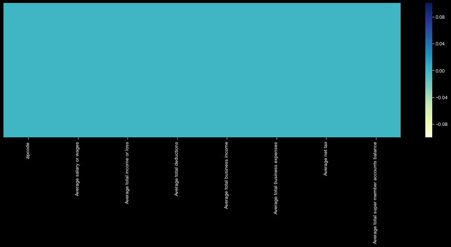

```python
plt.style.use ("dark_background")
plt.subplots(figsize=(18,5))
sns.heatmap(census_cleaned_data.isnull(),yticklabels=False,cbar=True,
            cmap='YlGnBu')
```

# Interpretation

From the above heatmap, we can conclude that there are no null values in the dataframe **`census_cleaned_Data`**

```python
air_cen_join=airbnb_cleaned_data.merge(census_cleaned_data,how='inner')
print("Shape of the dataframe after joining Airbnb & Census datasets is:",air_cen_join.shape)
air_cen_join.head()
```

```
Shape of the dataframe after joining Airbnb & Census datasets is: (35361, 58)
```

|  | name | description | experiences_offered | transit | host_id | host_name | host_location | host_response_rate | host_is_superhost | host_listings_count | ... | house_rules | amenities_count | price_class | Average salary or wages | Average total income or loss | Average total deductions | Average total business income | Average total business expenses | Average net tax | Average total super member accounts balance |
| --- | --- | --- | --- | --- | --- | --- | --- | --- | --- | --- | --- | --- | --- | --- | --- | --- | --- | --- | --- | --- | --- |
| 0 | An Oasis in the City | Very central to the city which can be reached ... | none | It is 7 minutes walk to the Kings Cross.train ... | 40855 | Colleen | Potts Point, New South Wales, Australia | 50 | 0 | 1.000 | ... | Be considerate. No showering after 2330h. | 23 | 0 | 83593 | 101062 | 4393 | 99864 | 61639 | 35418 | 159994 |
| 1 | Harbour views. Massive apartment | Our unit is the perfect place to stay to base ... | none | Getting to and from the unit is best done via ... | 425305 | Dan | Sydney, New South Wales, Australia | 100 | 0 | 1.000 | ... | Have a great time during your stay. Let me kno... | 37 | 2 | 83593 | 101062 | 4393 | 99864 | 61639 | 35418 | 159994 |
| 2 | Potts Point: Lrg Mod Art Deco Apt, Walk Everyw... | This large modern studio apartment (50 sqm) on... | none | You are extremely close to all public transpor... | 733574 | Tobias | Sydney, New South Wales, Australia | 100 | 1 | 4.000 | ... | No parties, smoking or pets unfortunately. Pl... | 23 | 0 | 83593 | 101062 | 4393 | 99864 | 61639 | 35418 | 159994 |
| 3 | Great Location, Paris End, Potts Point Sydney | This immaculate apartment is private, modern a... | none | One of the best things about Potts Point is ho... | 519412 | Sarah | Sydney, New South Wales, Australia | 0 | 0 | 1.000 | ... | This apartment is my home, so I invite you to ... | 24 | 0 | 83593 | 101062 | 4393 | 99864 | 61639 | 35418 | 159994 |
| 4 | Potts Point Apt - Sunny with Views | Furnished, sunny, 1 bedroom apartment with a b... | none | It is two minutes walk to the nearest train st... | 1261500 | Hugh | Sydney, New South Wales, Australia | 100 | 0 | 5.000 | ... | ★ Prior to the day of your check-in, ONLY CONT... | 38 | 1 | 83593 | 101062 | 4393 | 99864 | 61639 | 35418 | 159994 |

5 rows × 58 columns

# Interpretation

# `Logistic Regression on Price Class (after joining Airbnb dataset with Census dataset)`

```python
y1=air_cen_join["price_class"]
X1=air_cen_join.drop(["name","description","experiences_offered","transit","host_id","host_name","host_location","street","neighbourhood","neighbourhood_cleansed","city",
                            "street","state","zipcode","market","smart_location","property_type","amenities","price","price_class","house_rules"],axis=1)
```

```python
X1_train,X1_test,y1_train,y1_test=train_test_split(X1,y1, test_size=0.3)
```

# Interpretation

We are splitting the data in two array of test and train. We are splitting the data because first we will train our model and later test our model on test data to get the accuracy score of the model built.

```python
X1_train= StandardScaler(with_mean=False).fit_transform(X1_train)
X1_test=StandardScaler(with_mean=False).fit_transform(X1_test)
```

# Interpretation

We are standardising the X array to bring the data on to same scale.

```python
log_model_join=LogisticRegression()
log_model_join.fit(X1_train,y1_train)
```

```
LogisticRegression(C=1.0, class_weight=None, dual=False, fit_intercept=True,
                   intercept_scaling=1, l1_ratio=None, max_iter=100,
                   multi_class='warn', n_jobs=None, penalty='l2',
                   random_state=None, solver='warn', tol=0.0001, verbose=0,
                   warm_start=False)
```

# Interpretation

We are fitting **`logistic regression`** to the training dataset to predict the price_class variable values.

```python
print("Score of the Logistic Model is : ",log_model_join.score(X1_test,y1_test))
```

```
Score of the Logistic Model is :  0.7124139881232916
```

# `KNN Model on Price Class (after joining Airbnb dataset & Census dataset)`

```python
knn_model_join = KNeighborsClassifier(n_neighbors=1)
knn_model_join.fit(X1_train, y1_train)
knn_model_join.fit(X1_train,y1_train)
y1_pred=knn_model_join.predict(X1_test)
```

# Interpretation

We are fitting the **`Knn`** model for the trainig dataset and prediciting the **`price_class`** in y array with nearest neighbours as 1.

```python
print("Accuracy of KNN model:", accuracy_score(y1_test,y1_pred))
```

```
Accuracy of KNN model: 0.660571213120935
```

# Interpretation

We are checking the accuracy score of the **`KNN model`** and find that is around 0.66 for this dataset.

# Comparing the Logistic & KNN models for Price Class of Airbnb dataset and Joined dataset.

We find that the **`Logistic Model`** score increases after joining the dataset and same goes for the **`KNN`** model as well , this is because we are adding more features(columns) to the model.

But still , **`Logistic model has better score than the KNN model.`**

```python
neighbours = list(range(6,12))
cv_scores = []
for k in neighbours:
    knn_model_join = KNeighborsClassifier(n_neighbors=k)
    scores = cross_val_score(knn_model_join, X1_train, y1_train, cv=10, scoring='accuracy')
    cv_scores.append(scores.mean())
```

# Interpretation

```python
missclass_error = [1 - x for x in cv_scores]
optimal_K = neighbours[missclass_error.index(min(missclass_error))]
print("The optimal number of neighbors is {}".format(optimal_K))
```

```
The optimal number of neighbors is 10
```

# Interpretation

We have calculated the misclassification error and find the optimal value of K. The optimal K value is 10.

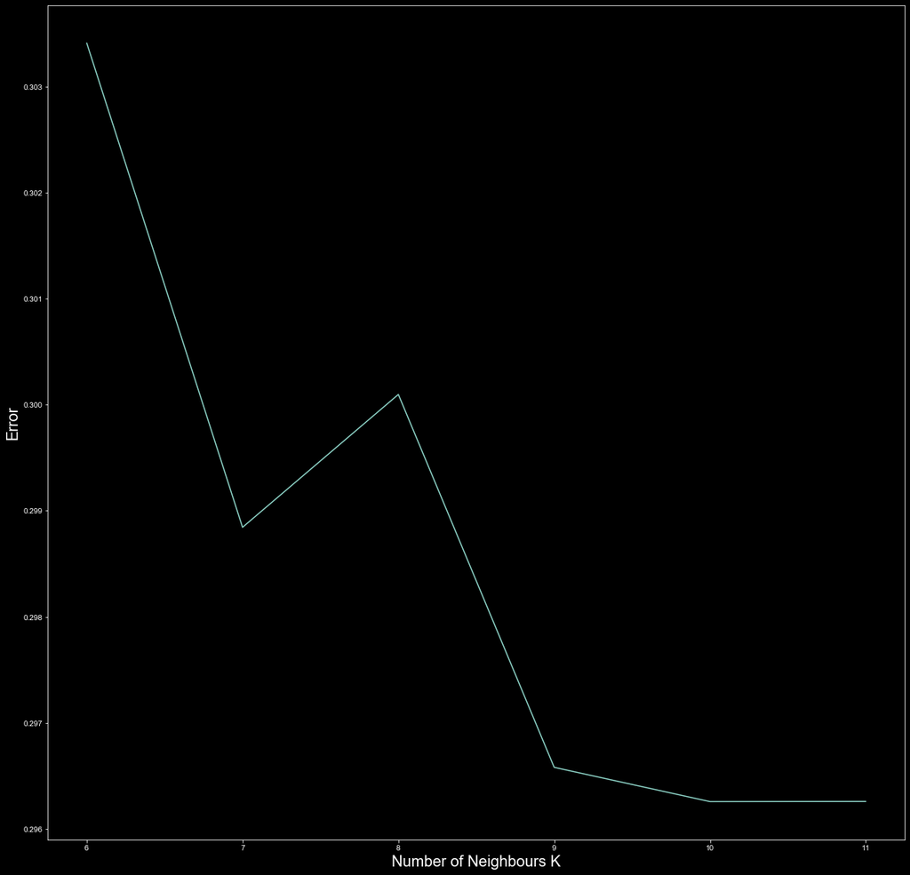

```python
plt.plot(neighbours, missclass_error)
plt.xlabel("Number of Neighbours K",fontsize=20)
plt.ylabel("Error",fontsize=20)
plt.show()
```

# Interpretation

# `Linear regression`:

```python
Yreg=air_cen_join["price"]
Xreg=air_cen_join.drop(["name","description","experiences_offered","transit","host_id","host_name","host_location","street","neighbourhood","neighbourhood_cleansed","city",
                            "street","state","zipcode","market","smart_location","property_type","amenities","price","price_class","house_rules"],axis=1)
```

```python
Xtrain, Xtest, ytrain, ytest = train_test_split(Xreg,Yreg,test_size=0.3,random_state=0)
```

```python
xrtrain = StandardScaler(with_mean=False).fit_transform(Xtrain)
xrtest = StandardScaler(with_mean=False).fit_transform(Xtest)
```

# Interpretation

We are standardising the training dataset to the base values.

```python
lm = LinearRegression()
lm.fit(xrtrain, ytrain)
```

```
LinearRegression(copy_X=True, fit_intercept=True, n_jobs=None, normalize=False)
```

# Interpretation

We are fitting **`linear model`** to the Joined dataset.

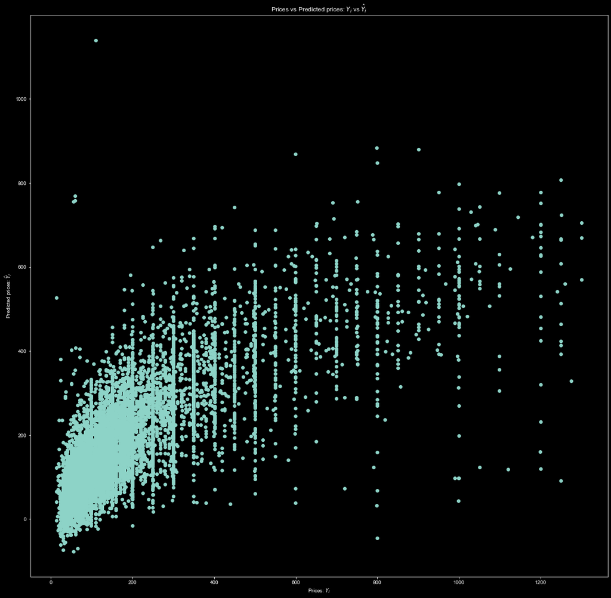

```python
Y_pred = lm.predict(xrtest)
plt.scatter(ytest, Y_pred)
plt.xlabel("Prices: $Y_i$")
plt.ylabel("Predicted prices: $\hat{Y}_i$")
plt.title("Prices vs Predicted prices: $Y_i$ vs $\hat{Y}_i$")
plt.show()
```

# Interpretation:

We can see that the data points are not aligned in a straight line which shows that the model is not fitting on to the data.

```python
predicted = lm.predict(xrtest)
mse = ((np.array(ytest)-predicted)**2).sum()/len(ytest)
r2 = r2_score(ytest, predicted)
print("MSE:", mse)
print("R Squared:", r2)
```

```
MSE: 12739.996899712745
R Squared: 0.5736545825396919
```

# Interpretation:

The r2 score on the linear regression model after joining the census data is 0.5736 which can still be increased.

# `Decison Tree Regressor`

```python
DTree=DecisionTreeRegressor(min_samples_leaf=.0001)
DTree.fit(xrtrain,ytrain)
y_predict=DTree.predict(xrtest)
from sklearn.metrics import r2_score
r2_score(ytest,y_predict)
```

```
0.4571367243541199
```

# Interpretation:

```python
%%time
w= [3,4,6,7,8,9]
crossvalidationscores2 = []
for i, perplexity in enumerate(w):

    dtw=DecisionTreeRegressor(max_depth=perplexity)
    scores2= cross_val_score(dtw,xrtrain,ytrain , cv=5, scoring='r2')
    crossvalidationscores2.append(scores2.mean())
MSE2 = [1 - x for x in crossvalidationscores2]
optimal_d3=(w[MSE2.index(min(MSE2))])
```

```
Wall time: 5.45 s
```

```
The optimal depth = 7
```

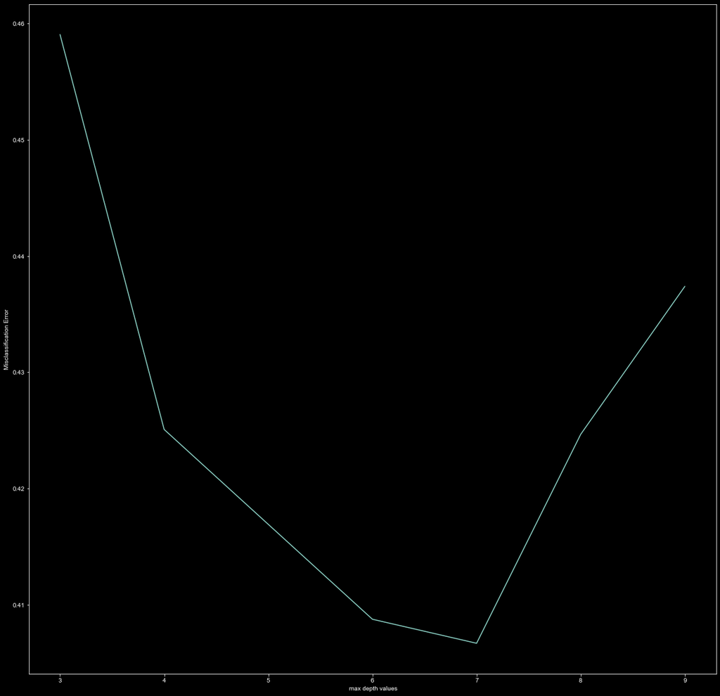

```
the misclassification error for each value of max depth is :  [0.45905350309287096, 0.4250746903841063, 0.408746488973868, 0.40668127985188673, 0.4246609919355253, 0.4373868626909394]
```

```python
print('\nThe optimal depth =',optimal_d3)
plt.plot(w, MSE2)
plt.xlabel(' max depth values')
plt.ylabel('Misclassification Error')
plt.show()
print("the misclassification error for each value of max depth is : ", MSE2)
print(" ")
```

# Interpretation:

```python
DTree=DecisionTreeRegressor(max_depth=6,min_samples_leaf=.0001)
DTree.fit(xrtrain,ytrain)
y_predict=DTree.predict(xrtest)
from sklearn.metrics import r2_score
r2_score(ytest,y_predict)
```

```
0.6016256596766403
```

# Interpretation:

# `Using neural network`

```python
nreg=MLPRegressor()
nreg.fit(xrtrain,ytrain)
```

```
MLPRegressor(activation='relu', alpha=0.0001, batch_size='auto', beta_1=0.9,
             beta_2=0.999, early_stopping=False, epsilon=1e-08,
             hidden_layer_sizes=(100,), learning_rate='constant',
             learning_rate_init=0.001, max_iter=200, momentum=0.9,
             n_iter_no_change=10, nesterovs_momentum=True, power_t=0.5,
             random_state=None, shuffle=True, solver='adam', tol=0.0001,
             validation_fraction=0.1, verbose=False, warm_start=False)
```

# Interpretation

We are fiiting **`Neural Network`** to the training dataset

```python
print("Score of training dataset is :",nreg.score(xrtrain, ytrain, sample_weight=None))
print("Score of testing dataset is :",nreg.score(xrtest, ytest, sample_weight=None))
```

```
Score of training dataset is : 0.6736709738033213
Score of testing dataset is : 0.6673156659492236
```

# Interpretation

We are checking the score of the training and testing dataset and find that out it is 0.673 and 0.667 respectively with default parameters.

# Performing Neural Network with **`maximum_iterations`** = 600

```python
nregf=MLPRegressor(max_iter=600)
nregf.fit(xrtrain,ytrain)
```

```
MLPRegressor(activation='relu', alpha=0.0001, batch_size='auto', beta_1=0.9,
             beta_2=0.999, early_stopping=False, epsilon=1e-08,
             hidden_layer_sizes=(100,), learning_rate='constant',
             learning_rate_init=0.001, max_iter=600, momentum=0.9,
             n_iter_no_change=10, nesterovs_momentum=True, power_t=0.5,
             random_state=None, shuffle=True, solver='adam', tol=0.0001,
             validation_fraction=0.1, verbose=False, warm_start=False)
```

```python
nregf.score(xrtest, ytest, sample_weight=None)
```

```
0.675488659823405
```

# Interpretation